# Reproducible Research: Peer Assessment 1

Bojan Zunar

18th June 2018

## Loading and preprocessing the data

Load the data. Process/transform the data (if necessary) into a format suitable for your analysis.

```r
library(dplyr)
library(ggplot2)
library(magrittr)

data <- read.csv("activity.csv")
```

## What is mean total number of steps taken per day?

Calculate the total number of steps taken per day. Make a histogram of the total number of steps taken each day.

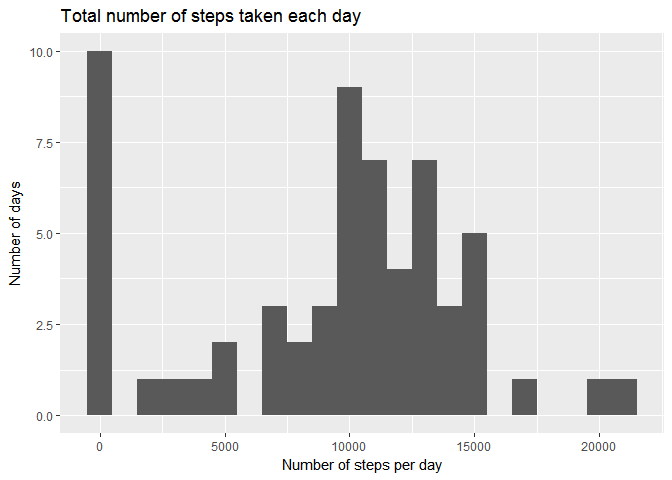

```r
data %>%
    group_by(date) %>%
    summarise(total = sum(steps, na.rm = TRUE)) %>%
    ggplot(., aes(total)) +
    geom_histogram(binwidth = 1000) +
    labs(title = "Total number of steps taken each day") +
    labs(x = "Number of steps per day") +
    labs(y = "Number of days")
```

Calculate and report the mean and median of the total number of steps taken per day.

```r
# calculate mean
data %>%
    group_by(date) %>%
    summarise(total = sum(steps, na.rm = TRUE)) %>%
    .$total %>%
    mean %>%
    cat("Mean number of steps taken each day: ", ., "\n")
```

```
## Mean number of steps taken each day:  9354.23
```

```r
# calculate median
data %>%
    group_by(date) %>%
    summarise(total = sum(steps, na.rm = TRUE)) %>%
    .$total %>%
    median %>%
    cat("Median number of steps taken each day: ", ., "\n")
```

```
## Median number of steps taken each day:  10395
```

## What is the average daily activity pattern?

Make a time series plot (i.e. type = “l”) of the 5-minute interval (x-axis) and the average number of steps taken, averaged across all days (y-axis).

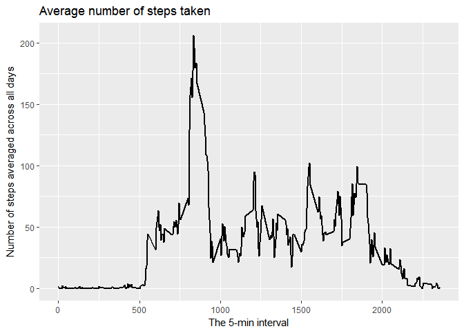

```r
data %>%
    group_by(interval) %>%
    summarise(mean = mean(steps, na.rm = TRUE)) %>%
    ggplot(., aes(x = interval, y = mean)) +
    geom_line(size = 1) +
    labs(title = "Average number of steps taken") +
    labs(x = "The 5-min interval") +
    labs(y = "Number of steps averaged across all days")
```

Which 5-minute interval, on average across all the days in the dataset, contains the maximum number of steps?

```r
data %>%
    group_by(interval) %>%
    summarise(mean = mean(steps, na.rm = TRUE)) %>%
    .$mean %>%
    which.max %>%
    data$interval[.]
```

```
## [1] 835
```